# Logistic Regression

Logistic Regression is used for classification. In linear regression the response varible (Y) is quantitative, but in many situations the response variable can be qualitative or categorical. Predicting a qualitative response for an observation can be referred to as classifying that observation, since it involves assigning the observation to a category, or class. On the other hand, often the methods used for classification first predict the probability of each of the categories of a qualitative variable, as the basis for making the classification. In this sense they also behave like regression methods.

There are many possible classification techniques, or classifiers, that one might use to predict a qualitative response. Three of the most qualitative classification classifiers widely-used are: logistic regression, linear discriminant analysis, and logistic K-nearest neighbors.

#### Example Classification problems:

1. A person arrives at the emergency room with a set of symptoms that could possibly be attributed to one of three medical conditions. Which of the three conditions does the individual have?
2. An online banking service must be able to determine whether or not a transaction being performed on the site is fraudulent, on the basis of the user’s IP address, past transaction history, and so forth.
3. On the basis of DNA sequence data for a number of patients with and without a given disease, a biologist would like to figure out which DNA mutations are deleterious (disease-causing) and which are not.

We use the logistic function to output a value ranging from 0 to 1. Based off of the probability we assign a class.

Sigmoid function: always produces results in a probability from 0 to 1 of belonging in the 1 class. That means we can set a cutoff point at 0.5, anything below it results in class 0, anything above is class 1.

After you train a logistic regression model on some training data, you will evaluate your model’s performance on some test data. You can use a confusion matrix to evaluate classification models.

#### Terminology

True Positive (TP) cases in which we perdicted positive and in reality the the test is positive

True Negative (TN) cases in which we perdicted negative and in reality the test is negative

False Positives (FP) cases in which we predicted positive and in reality the test is negative (type 1 error) (telling a man they are pregnant)

False Negatives (FN) cases in whch we predicted negative and in reality the test is positive (type 2 error) (telling a pregnant women that is visablly showing that she is not pregnant)

Misclassification rate (error rate) measures overall how often we are wrong.

#### Measuring Accuracy

To calculate the accuracy of the model you would take (TP + TN) / total

To calculate the misclassifiation rate you would take (FP + FN) / total

#### Getting started

You will need to import the following libraries:

1. tidyverse
2. ggthemes
3. Amelia
4. kableExtra
5. knitr
6. devtools
7. knitcitations

#### Explore the data

```r
kable(head(df.train)) %>%
    kable_styling(bootstrap_options = "condensed")
```

| PassengerId | Survived | Pclass | Name | Sex | Age | SibSp | Parch | Ticket | Fare | Cabin | Embarked |
| --- | --- | --- | --- | --- | --- | --- | --- | --- | --- | --- | --- |
| 1 | 0 | 3 | Braund, Mr. Owen Harris | male | 22 | 1 | 0 | A/5 21171 | 7.2500 |  | S |
| 2 | 1 | 1 | Cumings, Mrs. John Bradley (Florence Briggs Thayer) | female | 38 | 1 | 0 | PC 17599 | 71.2833 | C85 | C |
| 3 | 1 | 3 | Heikkinen, Miss. Laina | female | 26 | 0 | 0 | STON/O2. 3101282 | 7.9250 |  | S |
| 4 | 1 | 1 | Futrelle, Mrs. Jacques Heath (Lily May Peel) | female | 35 | 1 | 0 | 113803 | 53.1000 | C123 | S |
| 5 | 0 | 3 | Allen, Mr. William Henry | male | 35 | 0 | 0 | 373450 | 8.0500 |  | S |
| 6 | 0 | 3 | Moran, Mr. James | male | NA | 0 | 0 | 330877 | 8.4583 |  | Q |

Lets take a look at the structure of the data set

```r
str(df.train)
```

```
## 'data.frame':    891 obs. of  12 variables:
##  $ PassengerId: int  1 2 3 4 5 6 7 8 9 10 ...
##  $ Survived   : int  0 1 1 1 0 0 0 0 1 1 ...
##  $ Pclass     : int  3 1 3 1 3 3 1 3 3 2 ...
##  $ Name       : Factor w/ 891 levels "Abbing, Mr. Anthony",..: 109 191 358 277 16 559 520 629 417 581 ...
##  $ Sex        : Factor w/ 2 levels "female","male": 2 1 1 1 2 2 2 2 1 1 ...
##  $ Age        : num  22 38 26 35 35 NA 54 2 27 14 ...
##  $ SibSp      : int  1 1 0 1 0 0 0 3 0 1 ...
##  $ Parch      : int  0 0 0 0 0 0 0 1 2 0 ...
##  $ Ticket     : Factor w/ 681 levels "110152","110413",..: 524 597 670 50 473 276 86 396 345 133 ...
##  $ Fare       : num  7.25 71.28 7.92 53.1 8.05 ...
##  $ Cabin      : Factor w/ 148 levels "","A10","A14",..: 1 83 1 57 1 1 131 1 1 1 ...
##  $ Embarked   : Factor w/ 4 levels "","C","Q","S": 4 2 4 4 4 3 4 4 4 2 ...
```

As you can see there is a total of 11 features, one thing we need to do is determine if there is an NA’s or Nulls in the data set. One way to do this is by using the ‘Ameila’ package and creating a missing map.

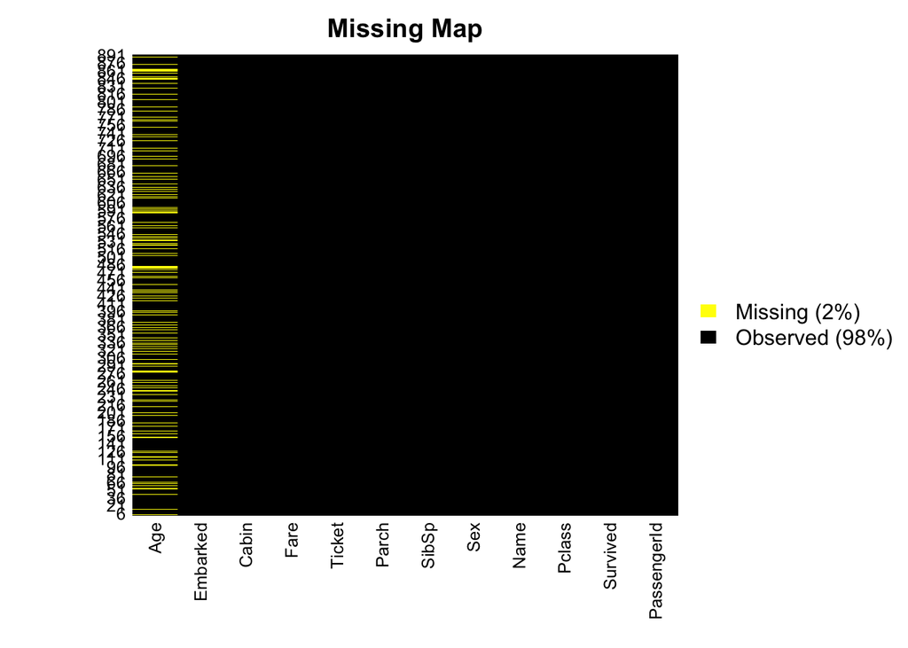

```r
missmap(df.train, main = 'Missing Map', col = c('yellow', 'black'), legend = TRUE)
```

As you can see the Age column as a significant amount of missing data, one way to solve this is to create a function that imputs the median age by Pclass. Lets take a look at a boxplot and determine the medain age by Pclass.

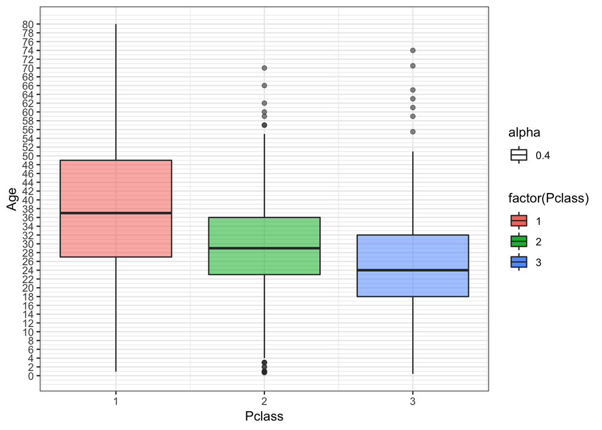

```r
pl <- ggplot(df.train, aes(Pclass, Age))
pl <- pl + geom_boxplot(aes(group = Pclass, fill = factor(Pclass), alpha = 0.4))
pl + scale_y_continuous(breaks = seq(min(0), max(80),2)) + theme_bw()
```

As you can see the median age by Pclass is 37, 29 and 24 respectively. This makes sense as we would assume that the older you are the higher class you will be able to afford.

Now that we have visualized the ages lets build a function to create imputation of age based on class.

```r
impute_age <- function(age, class){
    out <- age
    for (i in 1:length(age)){
        if (is.na(age[i])){
          if (class[i] == 1){
                out[i] <- 37
            }else if (class[i] == 2){
                out[i] <- 29
            }else{
                out[i] <- 24
            }
        }else{
            out[i] <-  age[i]
        }
      }
    return(out)
}
```

The above function will look through all the ages and determine if the age is blank it will place the median age based on the class of the individual. If the age is already present it will simply keep the age.

Now pass the ages to the impute_age functio and assign it to fixed.ages

```r
fixed.ages <-  impute_age(df.train$Age, df.train$Pclass)
```

Now we will have to take fixed.ages and replace the ages in the ages column. We can do this by assinging fixed.ages to the data frame column ages.

```r
df.train$Age <- fixed.ages
```

Lets take another look at the Missing Map to ensure our assignments worked.

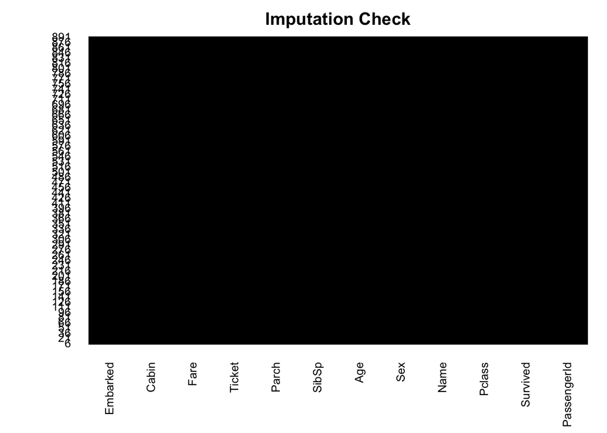

```r
missmap(df.train, main = 'Imputation Check', col = c('yellow', 'black'),legend = FALSE)
```

As you can see there is no more missing ages, the function worked.

Lets take another look at the structure of the data to determine what columns we want to use in the model.

```r
str(df.train)
```

```
## 'data.frame':    891 obs. of  12 variables:
##  $ PassengerId: int  1 2 3 4 5 6 7 8 9 10 ...
##  $ Survived   : int  0 1 1 1 0 0 0 0 1 1 ...
##  $ Pclass     : int  3 1 3 1 3 3 1 3 3 2 ...
##  $ Name       : Factor w/ 891 levels "Abbing, Mr. Anthony",..: 109 191 358 277 16 559 520 629 417 581 ...
##  $ Sex        : Factor w/ 2 levels "female","male": 2 1 1 1 2 2 2 2 1 1 ...
##  $ Age        : num  22 38 26 35 35 24 54 2 27 14 ...
##  $ SibSp      : int  1 1 0 1 0 0 0 3 0 1 ...
##  $ Parch      : int  0 0 0 0 0 0 0 1 2 0 ...
##  $ Ticket     : Factor w/ 681 levels "110152","110413",..: 524 597 670 50 473 276 86 396 345 133 ...
##  $ Fare       : num  7.25 71.28 7.92 53.1 8.05 ...
##  $ Cabin      : Factor w/ 148 levels "","A10","A14",..: 1 83 1 57 1 1 131 1 1 1 ...
##  $ Embarked   : Factor w/ 4 levels "","C","Q","S": 4 2 4 4 4 3 4 4 4 2 ...
```

In order to ensure the model works correctly we will have to remove some columns as they would simply complicate the model because there are to many levels associated with the factor. Take names for instance, each row contains a name of an individual that was on the titanic, this information is irrelevant to whether the individual survived or not so we will remove it. We will also remove PassengerIf, Ticket, Cabin, and Parch as they are also irrelevant in determining survival.

```r
df.train <- df.train %>%
    select(-PassengerId, -Name, -Ticket, -Cabin, -Parch)
```

Now lets take a look at the head of the data frame.

```r
head(df.train)
```

|  | Survived | Pclass | Sex | Age | SibSp | Fare | Embarked |
| --- | --- | --- | --- | --- | --- | --- | --- |
| 1 | 0 | 3 | male | 22 | 1 | 7.2500 | S |
| 2 | 1 | 1 | female | 38 | 1 | 71.2833 | C |
| 3 | 1 | 3 | female | 26 | 0 | 7.9250 | S |
| 4 | 1 | 1 | female | 35 | 1 | 53.1000 | S |
| 5 | 0 | 3 | male | 35 | 0 | 8.0500 | S |
| 6 | 0 | 3 | male | 24 | 0 | 8.4583 | Q |

Next, we will convert Survived, Pclass and Sibsp to factors instead of integers.

```r
df.train$Survived <- as.factor(df.train$Survived)
df.train$Pclass <- as.factor(df.train$Pclass)
df.train$SibSp <- as.factor(df.train$SibSp)
```

Verify the new structure

```r
str(df.train)
```

```
## 'data.frame':    891 obs. of  7 variables:
##  $ Survived: Factor w/ 2 levels "0","1": 1 2 2 2 1 1 1 1 2 2 ...
##  $ Pclass  : Factor w/ 3 levels "1","2","3": 3 1 3 1 3 3 1 3 3 2 ...
##  $ Sex     : Factor w/ 2 levels "female","male": 2 1 1 1 2 2 2 2 1 1 ...
##  $ Age     : num  22 38 26 35 35 24 54 2 27 14 ...
##  $ SibSp   : Factor w/ 7 levels "0","1","2","3",..: 2 2 1 2 1 1 1 4 1 2 ...
##  $ Fare    : num  7.25 71.28 7.92 53.1 8.05 ...
##  $ Embarked: Factor w/ 4 levels "","C","Q","S": 4 2 4 4 4 3 4 4 4 2 ...
```

#### Building the model

Since we are calculating a logistic regression we use the function glm (general linear model) and assign it to log.model. We have to add a few more cavets to the equation. Since we are determining whether someone survived or not we assign the Surrived feature as the first argument seperated by the tilda symbol, the “.” represents ‘everything’ as in the rest of the features (Pclass, Age, Sex, etc.). The family argument is a description of the error distribution we choose binomial since we are trying to determine if someone survived (1) or didn’t (0). Link simply tells the binomial function to use the logistic regression.

```r
log.model <- glm(Survived ~ ., family = binomial(link = 'logit'), data = df.train)
```

#### Summary of the model

```r
summary(log.model)
```

```
##
## Call:
## glm(formula = Survived ~ ., family = binomial(link = "logit"),
##     data = df.train)
##
## Deviance Residuals:
##     Min       1Q   Median       3Q      Max
## -2.8567  -0.5970  -0.4081   0.6023   2.5256
##
## Coefficients:
##               Estimate Std. Error z value Pr(>|z|)
## (Intercept)  1.869e+01  1.652e+03   0.011 0.990972
## Pclass2     -1.088e+00  3.050e-01  -3.567 0.000361 ***
## Pclass3     -2.291e+00  3.088e-01  -7.417 1.20e-13 ***
## Sexmale     -2.658e+00  1.986e-01 -13.385  < 2e-16 ***
## Age         -4.381e-02  8.407e-03  -5.211 1.88e-07 ***
## SibSp1       1.241e-01  2.129e-01   0.583 0.559832
## SibSp2      -2.011e-01  5.235e-01  -0.384 0.700810
## SibSp3      -2.080e+00  7.133e-01  -2.916 0.003544 **
## SibSp4      -1.592e+00  7.392e-01  -2.154 0.031271 *
## SibSp5      -1.592e+01  9.612e+02  -0.017 0.986787
## SibSp8      -1.599e+01  7.585e+02  -0.021 0.983182
## Fare         1.769e-03  2.310e-03   0.766 0.443690
## EmbarkedC   -1.459e+01  1.652e+03  -0.009 0.992955
## EmbarkedQ   -1.463e+01  1.652e+03  -0.009 0.992934
## EmbarkedS   -1.494e+01  1.652e+03  -0.009 0.992787
## ---
## Signif. codes:  0 '***' 0.001 '**' 0.01 '*' 0.05 '.' 0.1 ' ' 1
##
## (Dispersion parameter for binomial family taken to be 1)
##
##     Null deviance: 1186.66  on 890  degrees of freedom
## Residual deviance:  771.26  on 876  degrees of freedom
## AIC: 801.26
##
## Number of Fisher Scoring iterations: 15
```

The p-value for each term tests the null hypothesis that the coefficient is equal to zero (no effect). A low p-value (< 0.05) indicates that you can reject the null hypothesis. In other words, a predictor that has a low p-value is likely to be a meaningful addition to your model because changes in the predictor’s value are related to changes in the response variable (Survived). Conversely, a larger (insignificant) p-value suggests that changes in the predictor are not associated with changes in the response.

As you can tell by the model summary Pclass, Sex and Age are statistically significant in the survivability of the individual.

Now lets train the model to a test set so that we can determine the accuracy of the model.

#### Train vs Test checking the models accuracy

Lets create a test data frame by randomlly spliting the train data frame with a 70/30 split.

```r
split <- sample.split(df.train$Survived, SplitRatio = 0.7)
final.train <- subset(df.train, split == TRUE)
final.test <- subset(df.train, split == FALSE)
```

The sample.split function randomlly splits the data frame by the directed split ratio in our case 70% and assigns it a 1 (TRUE) and the other 30% a 0 (FALSE) to each observation. Finally, all we need to do is assign each subset (split) to either a train or test data frame.

Now lets retrain the model on the 70% split final.train.

```r
final.log.model <- glm(Survived ~ ., family = binomial(link = 'logit'), data = final.train)
```

Lets take a look at the summary of the new final log model.

```r
summary(final.log.model)
```

```
##
## Call:
## glm(formula = Survived ~ ., family = binomial(link = "logit"),
##     data = final.train)
##
## Deviance Residuals:
##     Min       1Q   Median       3Q      Max
## -2.9348  -0.5949  -0.3716   0.5504   2.6574
##
## Coefficients:
##               Estimate Std. Error z value Pr(>|z|)
## (Intercept)  1.958e+01  2.400e+03   0.008 0.993489
## Pclass2     -1.268e+00  3.720e-01  -3.409 0.000651 ***
## Pclass3     -2.739e+00  3.913e-01  -7.001 2.55e-12 ***
## Sexmale     -2.770e+00  2.453e-01 -11.293  < 2e-16 ***
## Age         -4.794e-02  1.048e-02  -4.573 4.80e-06 ***
## SibSp1       3.475e-01  2.599e-01   1.337 0.181217
## SibSp2       2.571e-01  6.268e-01   0.410 0.681641
## SibSp3      -2.328e+00  9.238e-01  -2.521 0.011717 *
## SibSp4      -1.679e+00  8.757e-01  -1.918 0.055169 .
## SibSp5      -1.563e+01  9.588e+02  -0.016 0.986992
## SibSp8      -1.544e+01  8.268e+02  -0.019 0.985100
## Fare        -5.285e-04  2.867e-03  -0.184 0.853735
## EmbarkedC   -1.497e+01  2.400e+03  -0.006 0.995021
## EmbarkedQ   -1.505e+01  2.400e+03  -0.006 0.994995
## EmbarkedS   -1.546e+01  2.400e+03  -0.006 0.994860
## ---
## Signif. codes:  0 '***' 0.001 '**' 0.01 '*' 0.05 '.' 0.1 ' ' 1
##
## (Dispersion parameter for binomial family taken to be 1)
##
##     Null deviance: 829.60  on 622  degrees of freedom
## Residual deviance: 515.84  on 608  degrees of freedom
## AIC: 545.84
##
## Number of Fisher Scoring iterations: 15
```

Now lets predict; we will assign the prediction to fitted.probabilities

```r
fitted.probabilities <-  predict(final.log.model, final.test, type = 'response')
```

Type is equal to response because we are trying to predict whether the lived or died or 0 and 1.

We want to assign the fitted.probabilities a 1 or a 0 so if the probability is greater than .5 then assign it a one else assign it a zero.

```r
fitted.results <- ifelse(fitted.probabilities > 0.5, 1, 0)
fitted.results
```

```
##   8   9  13  16  17  23  32  34  36  39  40  42  45  56  59  62  65  70
##   0   1   0   1   0   1   1   0   0   1   1   1   1   0   1   1   1   0
##  77  78  80  81  86  90  91  94  95  99 100 104 108 111 122 131 132 135
##   0   0   0   0   0   0   0   0   0   1   0   0   0   0   0   0   0   0
## 138 143 144 150 151 154 156 157 158 159 161 162 169 177 181 183 187 188
##   0   1   0   0   0   0   0   1   0   0   0   1   0   0   0   0   1   0
## 189 190 192 193 194 199 200 204 205 210 211 215 216 217 220 221 223 226
##   0   0   0   1   1   1   1   0   0   0   0   0   1   1   0   0   0   0
## 229 231 234 236 241 252 254 259 266 268 269 272 276 277 282 284 285 286
##   0   1   0   1   1   1   0   1   0   0   1   0   1   0   0   0   0   0
## 287 288 289 290 292 299 303 307 308 315 320 327 330 335 336 337 338 339
##   0   0   0   1   1   0   0   1   1   0   1   0   1   1   0   1   1   0
## 341 342 344 347 350 354 359 360 363 364 365 366 367 368 370 372 373 383
##   1   1   0   1   0   0   1   1   0   0   0   0   1   1   1   0   0   0
## 384 390 393 397 398 401 403 406 408 410 411 414 416 422 436 437 438 439
##   1   1   0   0   0   0   1   0   1   0   0   0   1   0   1   1   1   0
## 442 445 449 453 455 457 458 463 464 470 476 478 482 484 493 494 499 503
##   0   0   1   1   0   0   1   0   0   1   0   0   0   0   0   0   1   1
## 507 510 511 517 533 537 539 541 545 546 550 554 555 562 566 570 574 579
##   1   0   0   1   0   0   0   1   0   0   1   0   1   0   0   0   1   1
## 580 581 584 586 587 590 594 596 598 606 607 615 617 633 634 635 637 646
##   0   1   1   1   0   0   1   0   0   0   0   0   0   1   0   0   0   0
## 648 650 651 655 660 662 663 669 671 688 690 696 700 706 713 714 715 722
##   0   1   0   1   0   0   0   0   1   0   1   0   0   0   0   0   0   0
## 724 725 730 732 736 738 739 749 752 753 762 764 766 770 771 777 782 783
##   0   1   1   0   0   0   0   1   0   0   0   1   1   0   0   0   1   0
## 784 787 790 792 795 801 802 809 812 818 819 821 834 839 841 844 849 852
##   0   1   0   0   0   0   1   0   0   0   0   1   0   0   0   0   0   0
## 854 856 858 862 863 866 867 869 870 871 872 873 874 879 883 889
##   1   1   0   0   1   1   1   0   0   0   1   0   0   0   1   1
```

Lets determine the error

```r
missClassError <-  mean(fitted.results != final.test$Survived)
missClassError
```

```
## [1] 0.2014925
```

Finally, we will check for accuracy and assign the class error to accuracy and call accuracy to determine the result.

```r
accuracy <- 1 - missClassError
accuracy
```

```
## [1] 0.7985075
```

Lastly, we will create a confusion matrix

```r
table(final.test$Survived, fitted.probabilities > 0.5)
```

```
##
##     FALSE TRUE
##   0   143   22
##   1    32   71
```

#### Breaking down the confusion matrix

0 and false (TN: True Negative) 0 and true (FP: False Positive) 1 and False (FN: False Negative) 1 and True (TP: True Positive)

Source:

Udemy - Data Science and Machine Learning Bootcamp with R (Jose Portilla)

An Intro to Statistical Learning with Applications in R (Gareth James, et al.) http://www-bcf.usc.edu/~gareth/ISL/ISLR%20Sixth%20Printing.pdf